# Getting started with wrGraph

Wolfgang Raffelsberger

2026-04-28

## Introduction

This package contains a collection of various plotting functions, mostly as an extension of packages wrMisc and wrProteo.

This package is available from [CRAN](https://cran.r-project.org/), you might also have to install wrMisc, too. If not yet installed, the lastest versions of this package can be installed like this :

```r
if(!requireNamespace("wrMisc", quietly=TRUE)) install.packages("wrMisc")   # required underneath
install.packages("wrGraph")
```

During this vignette we’ll also use the packages FactoMineR and factoextra, let’s test if they are installed and install if not yet present.

```r
if(!requireNamespace("ggplot2", quietly=TRUE)) install.packages("ggplot2")   # also required
if(!requireNamespace("FactoMineR", quietly=TRUE)) install.packages("FactoMineR")
if(!requireNamespace("factoextra", quietly=TRUE)) install.packages("factoextra")
```

You cat start the vignette for this package by typing :

```r
# access vignette :
browseVignettes("wrGraph")    #  ... and the select the html output
```

To get started, we need to load the packages wrMisc and [wrGraph (this package)](https://CRAN.R-project.org/package=wrGraph).

```r
library("wrMisc")
library("wrGraph")
# This is version no:
packageVersion("wrGraph")
```

```
#> [1] '1.3.15'
```

## Prepare Layout For Accomodating Multiple Smaller Plots

The function *partitionPlot()* prepares a matrix to serve as grid for segmenting the current device (ie the available plotting region). It aims to optimize the layout based on a given number of plots to accommodate. The user may choose if the layout should rather be adopted to landscape (default) or portrait geometry.

This might be useful in particular when during an analysis-pipeline it’s not known/clear in advance how many plots might be needed in a single figure space.

```r
## as the last column of the Iris-data is not numeric we choose -1
(part <- partitionPlot(ncol(iris)-1))
```

```
#>      [,1] [,2]
#> [1,]    1    2
#> [2,]    3    4
```

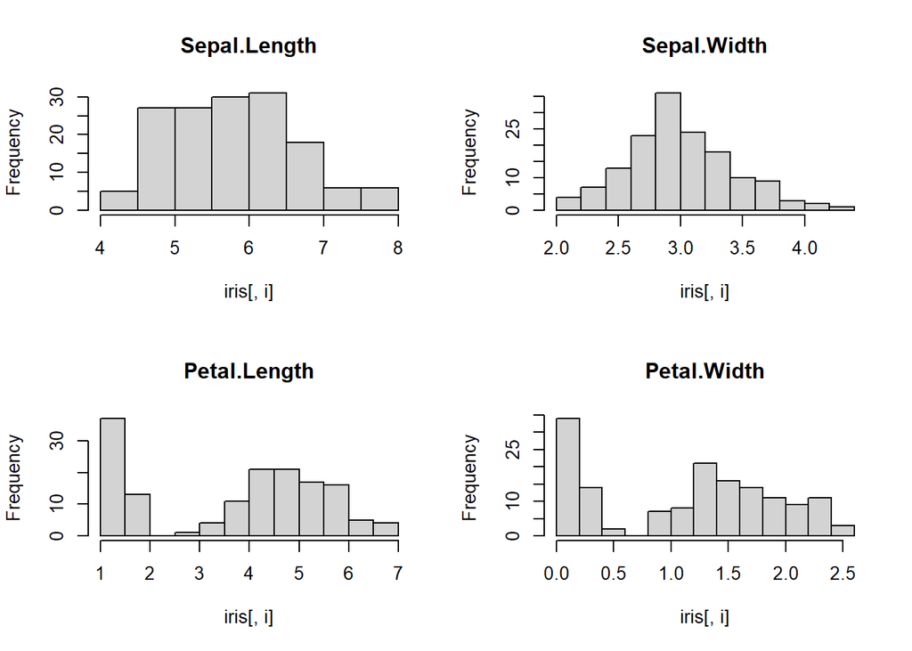

```r
layout(part)
for(i in colnames(iris)[-5]) hist(iris[,i], main=i)
```

## Optimal Legend Location

The function *checkForLegLoc()* allows to check which corner of a given graph is less crowded for placing a legend there. Basic legends can be added directly, or one can simply recuperate the location information.

```r
dat1 <- matrix(c(1:5,1,1:5,5), ncol=2)
grp <- c("abc","efghijk")
(legLoc <- checkForLegLoc(dat1, grp))
```

```
#> $showL
#> [1] TRUE
#>
#> $loc
#> [1] "bottomright"
#>
#> $nConflicts
#>     topleft    topright bottomright  bottomleft
#>           1           1           0           1
```

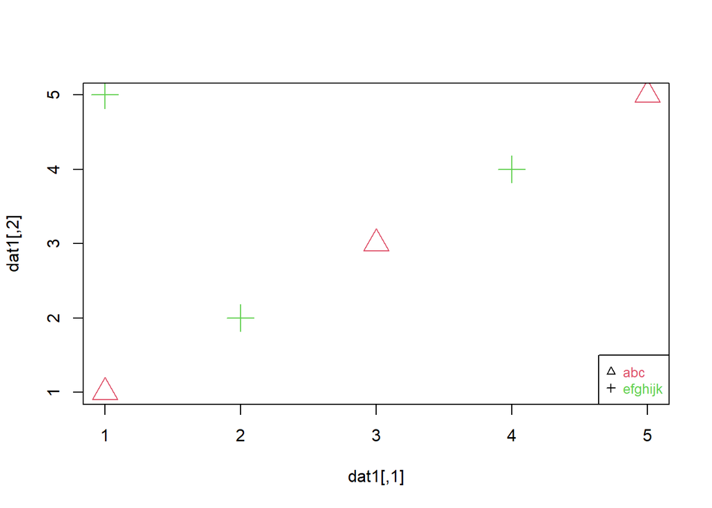

```r
# now with more graphical parameters (using just the best location information)
plot(dat1, cex=2.5, col=rep(2:3,3),pch=rep(2:3,3))
legLoc <- checkForLegLoc(dat1, grp, showLegend=FALSE)
legend(legLoc$loc, legend=grp, text.col=2:3, pch=rep(2:3), cex=0.8)
```

## One More Histogram Function …

Histograms are a very versatile tool for rapidly gaining insights in the distribution of data. This package presents a histogram function allowing to conveniently **work with log2-data** and (if desired) display numbers calculated back to linear values on the x-axis.

Default settings aim to give rather a quick overview, for “high resolution” representations one could set a high number of breaks or one might also consider other/alternative graphical representations. Some of the alternatives are shown later in this vignette.

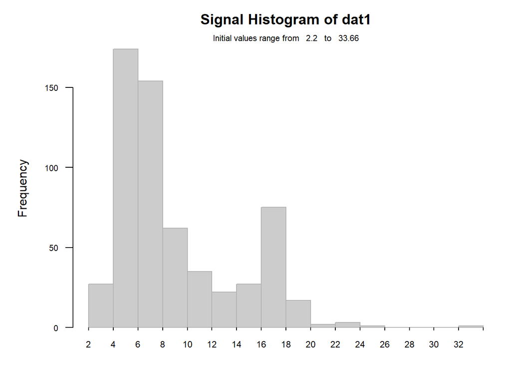

```r
set.seed(2016); dat1 <- round(c(rnorm(200,6,0.5), rlnorm(300,2,0.5), rnorm(100,17)),2)
dat1 <- dat1[which(dat1 <50 & dat1 > 0.2)]
histW(dat1, br="FD", isLog=FALSE)
```

One interesting feature is the fact that this fucntions can handle log-data (and display x-axis classes as linear) :

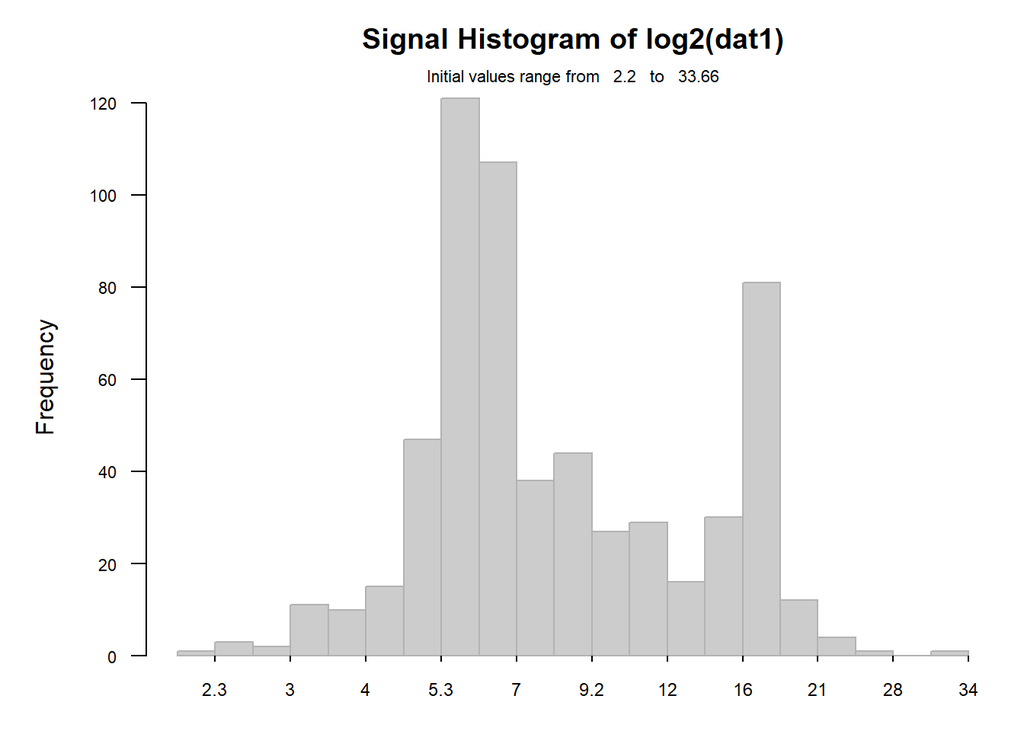

```r
## view as log, but x-scale in linear
histW(log2(dat1), br="FD", isLog=TRUE, silent=TRUE)
```

Now we can combine this with the previous segmentation to accomodate 4 histograms :

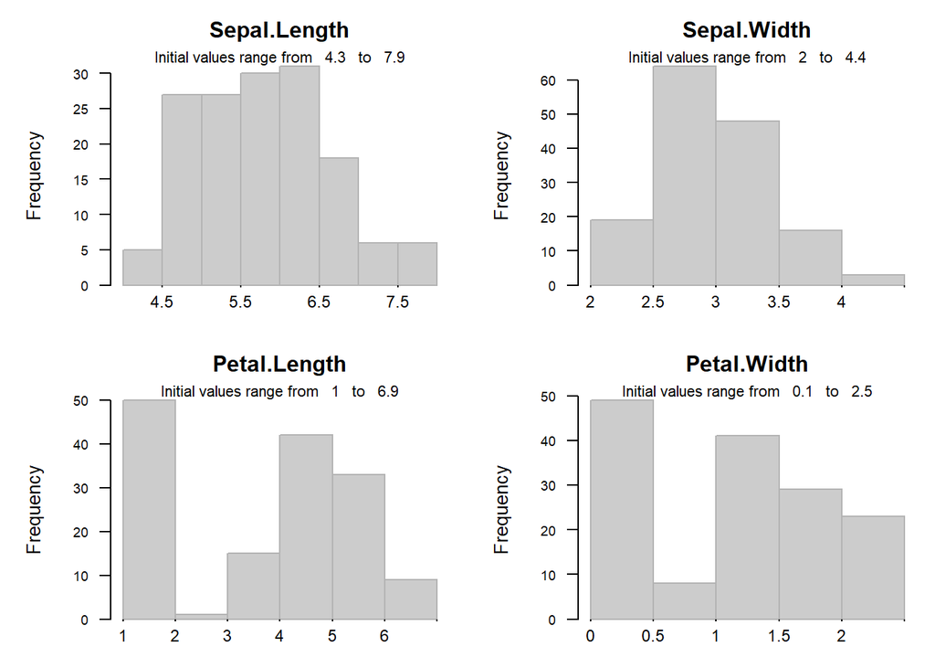

```r
## quick overview of distributions
layout(partitionPlot(4))
for(i in 1:4) histW(iris[,i], isLog=FALSE, tit=colnames(iris)[i])
```

### Small Histogram(s) as Legend

With some plots it may be useful to add small histograms for the x- and/or y-data.

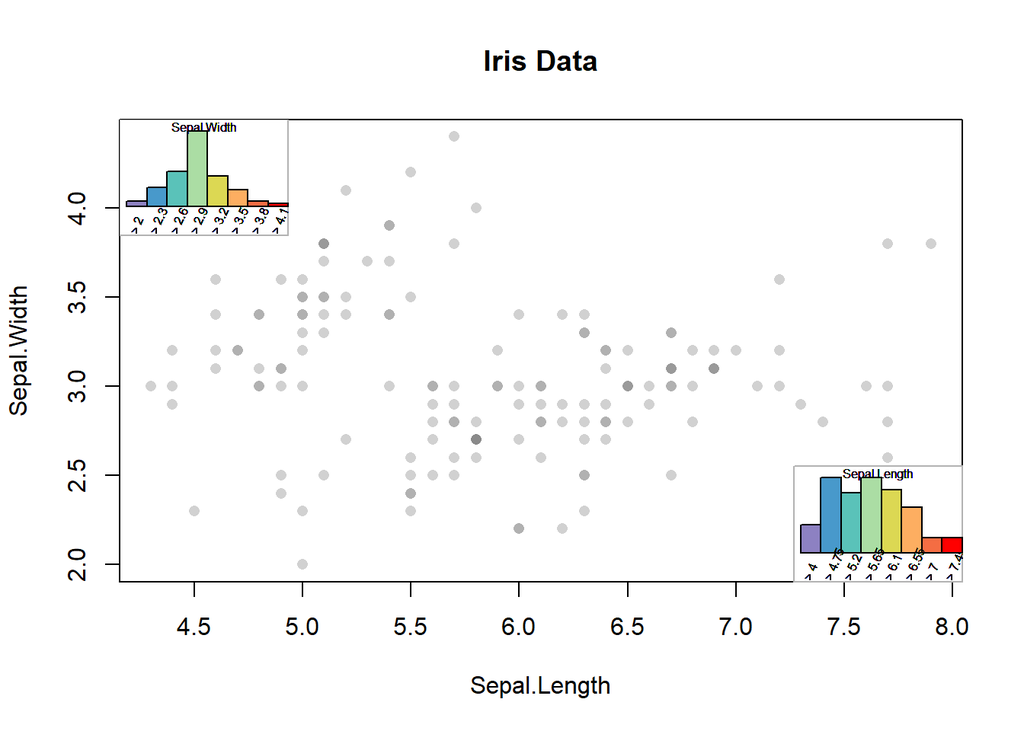

```r
layout(1)
plot(iris[,1:2], col=rgb(0.4,0.4,0.4,0.3), pch=16, main="Iris Data")
legendHist(iris[,1], loc="br", legTit=colnames(iris)[1], cex=0.5)
legendHist(iris[,2], loc="tl", legTit=colnames(iris)[2], cex=0.5)
```

## Violin Plots

[Violin plots](https://en.wikipedia.org/wiki/Violin_plot) or vioplots are basically an adaptation of plotting the [Kernel density estimation](https://en.wikipedia.org/wiki/Kernel_density_estimation) allowing to compare multiple data-sets. Please note, that although smoothed distributions please the human eye, some data-sets do not have such a continuous character.

Compared to the *vioplots* R from the popular package vioplot, the function provided here offers more flexibility for data-formats accepted (including data.frames and lists), coloring and display of n. All NA-values are ignored/eliminated and n gets adjusted accordingly. In the case of the Iris-data, there are no NAs and thus n is constant, in consequence the number of values (n) is displayed only once. However, frequently the number of values per data-set/violin n may vary (presence of NAs of list with vectors of different sizes).

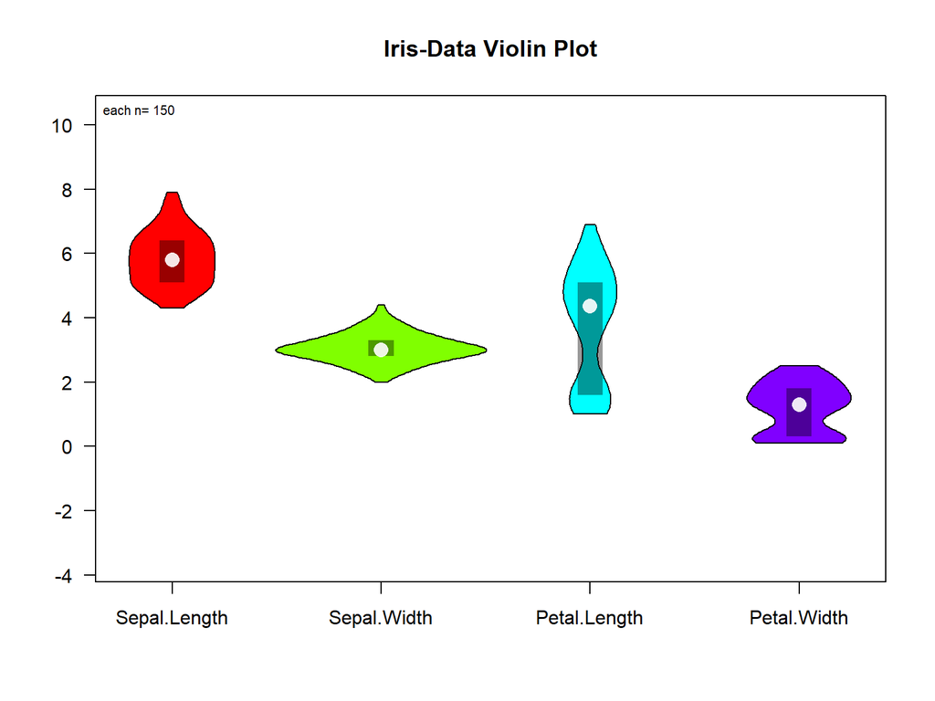

```r
vioplotW(iris[,-5], tit="Iris-Data Violin Plot")
```

The smoothing of the curves uses default parameters from the function *sm.density* from the package sm. In some cases the Kernel smoothing may appear to strong, this behaviour can be modified using the argument *hh* (which is passed on as argument *h* to the function *sm.density*).

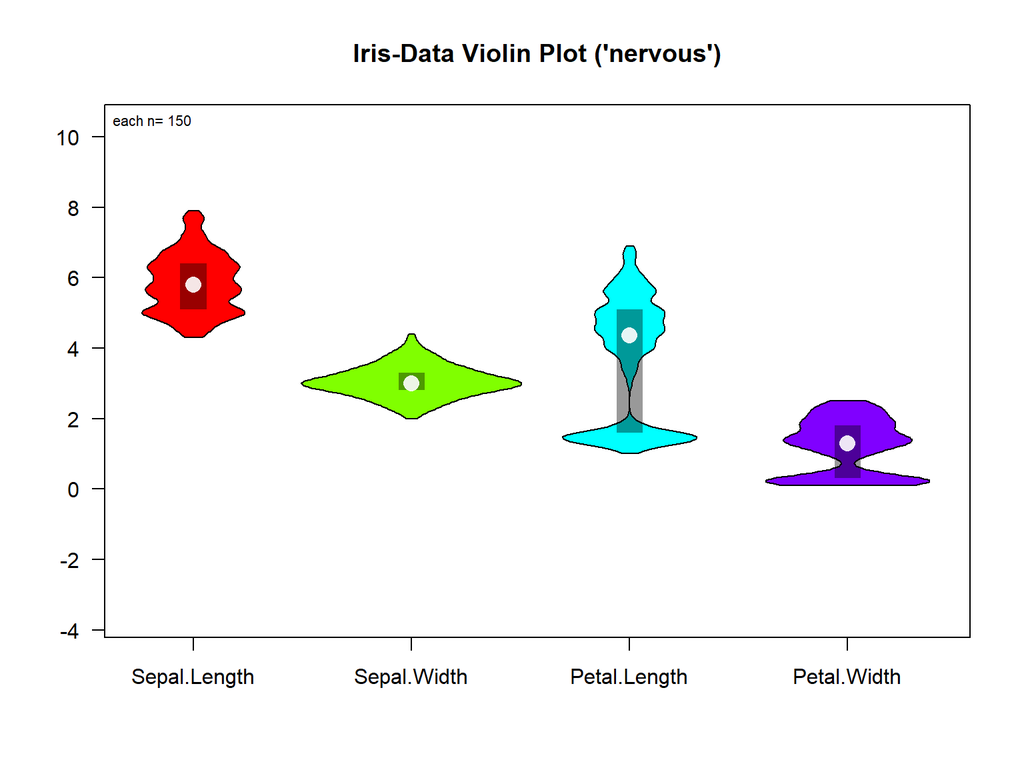

```r
## less smoothing
vioplotW(iris[,-5], tit="Iris-Data Violin Plot ('nervous')", hh=0.15)
```

### Paired Violin Plots

In order to compare a paired setup easier only half-violins can be drawn for each distribution and shown back-to-back using the argument *halfViolin*. With larger data-sets this may be more helpful than in the example shown below.

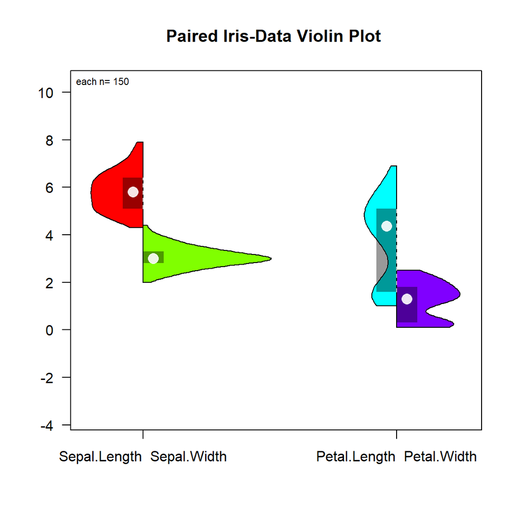

```r
## less smoothing
vioplotW(iris[,-5], tit="Paired Iris-Data Violin Plot ", halfViolin="pairwise")
```

## Plotting Sorted Values (‘Summed Frequency’)

This plot offers an alternative to histograms and density-plots. While histograms and density-plots are very intuitive, their interpretation may pose some difficulties due to the smoothing effect of Kernel-functions or the non-trivial choice of optimal width of bars (histogram) may influence interpretation.

As alternative, a plot is presented which basically reads like a summed frequency plot and has the main advantage, that all points of data may be easily displayed. Thus the resultant plot does not suffer from deformation due to binning or smoothing and offers maximal ‘resolution’.

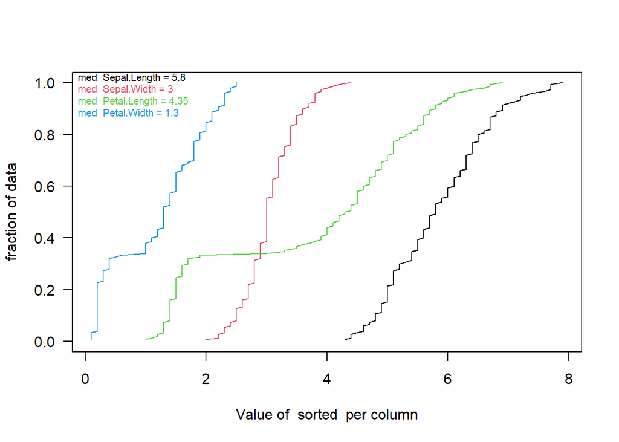

```r
cumFrqPlot(iris[,1:4])
```

For example, the Iris-data are rounded. As a result in the plot above the line is not progressing smooth but with more marked character of steps of stairs. To get the same conclusion one would need to increase the number of bars in a histogram very much, which would makes it in our experience more difficult to evaluate the same time the global distribution character.

At this plot you may note that the curves patal.width and petal.length look differently. On the previous vioplots you may have noticed the bimodal character of the values, again this plot may be helpful to identify distributions which are very difficult to see well using boxplots.

## Color-Code Numeric Content Of Matrix (Heatmap)

To get a quick overview of the distribution of data and, in particular, of local phenomena it is useful to express numeric values as colored boxes. The function *image()* from the graphic-package provides basic help.

Generally this type of display is called *heatmap*, however, most functions in R combine this directly with organizing by hierarchical clustering (*heatmap()* (package stats) or *heatmap.2()* from package [gplots](https://CRAN.R-project.org/package=wrMisc)).

Simple plotting without reorganizing rows and columns can be done using the function `imageW()` (from this package), offering convenient options for displaying row- and column-names. First of all, the 1st line of your data will show up on the top of the plot and not on the bottom, as it is the case with *image()* (since it starts counting from 0 at the bottom).

Using the argument *transp* you can decide if the data should be shown *as is* or rotated by 90 degrees (as in example below, equivalent to a `t()` on your data). Furthermore, the output can be produced using standard graphics or using the trellis/lattice framework. The latter includes also a convenient automatic legend for the color-codes used. Below, the first 40 lines of the Iris-dataset are used :

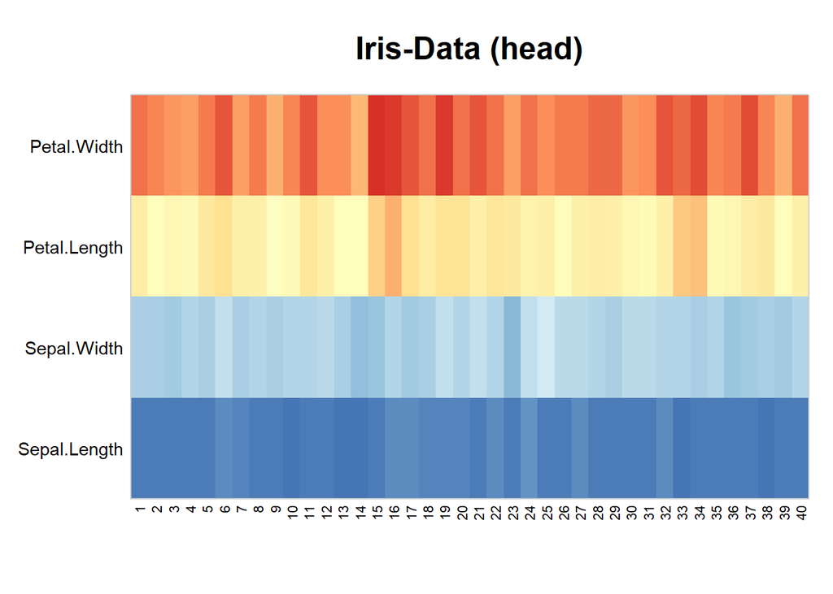

```r
par(mar=c(4, 5.5, 4, 1))
imageW(as.matrix(iris[1:40,1:4]), transp=FALSE, tit="Iris-Data (head)")
```

Here again the Iris-data plotted using the lattice/trellis framework :

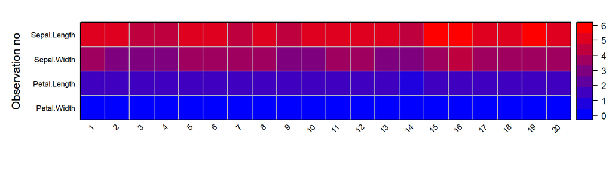

```r
imageW(as.matrix(iris[1:20,1:4]), latticeVersion=TRUE, transp=FALSE, col=c("blue","red"),
  rotXlab=45, yLab="Observation no", tit="Iris-Data (head)")
```

Note, by default this version forces the *aspect* argument of *levelplot()* to square shapes. In some cases it may be desirable to pass the color-gradient through the value of 0 at a predefined color (use the center element of tha argument *col*). One can also display the (rounded) values and choose a custom color for NA-values.

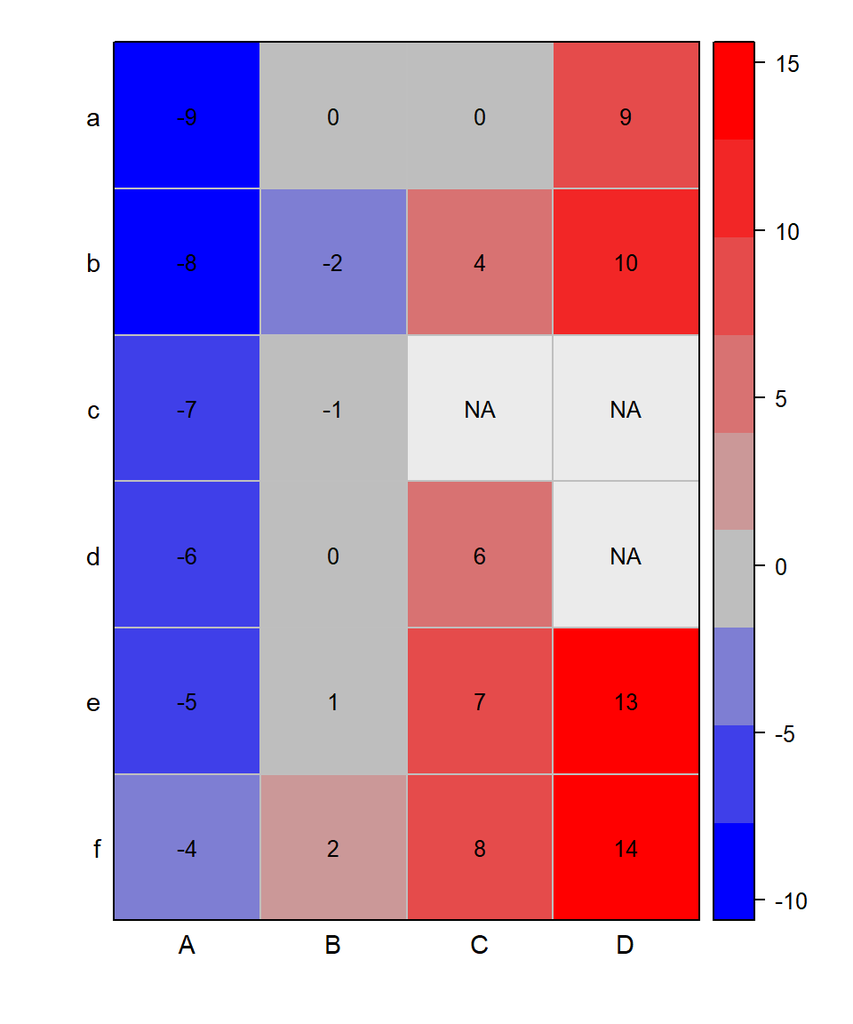

```r
ma1 <- matrix(-9:14, nc=4, dimnames=list(letters[1:6],LETTERS[1:4]))
ma1[1,2:3] <- 0
ma1[3,3] <- ma1[3:4,4] <- NA

imageW(ma1, latticeVersion=TRUE, col=c("blue","grey","red"), NAcol="grey92",
  rotXlab=0, cexDispl=0.8, tit="Balanced color gradient")
```

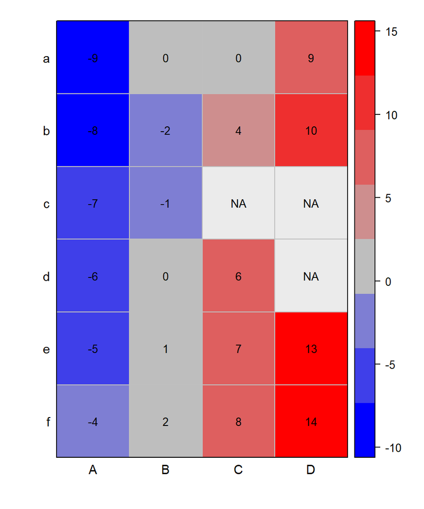

```r
imageW(ma1, latticeVersion=TRUE, col=c("blue","grey","red"), NAcol="grey92",
  rotXlab=0, nColor=8, cexDispl=0.8, tit="Balanced color gradient")
```

## Examine Counts Based On Variable Threshold Levels (for ROC curves)

The next plot is dedicated to visualize counting results with moving thresholds. While a given threshold criteria moves up or down the resulting number of values passing may not necessarily follow in a linear way. This function lets you follow multiple types of samples (eg type of leave in the Iris-data) in a single plot. In particular when constructing [ROC curves](https://en.wikipedia.org/wiki/Receiver_operating_characteristic) it may also be helpful to visualize the (absolute) counting data used underneath before determining TP and FP ratios. Typically used in context of benchmark-tests in proteomics.

```r
thr <- seq(min(iris[,1:4]), max(iris[,1:4])+0.1,length.out=100)
irisC <- sapply(thr,function(x) colSums(iris[,1:4] < x))
irisC <- cbind(thr,t(irisC))

  head(irisC)
```

```
#>            thr Sepal.Length Sepal.Width Petal.Length Petal.Width
#> [1,] 0.1000000            0           0            0           0
#> [2,] 0.1797980            0           0            0           5
#> [3,] 0.2595960            0           0            0          34
#> [4,] 0.3393939            0           0            0          41
#> [5,] 0.4191919            0           0            0          48
#> [6,] 0.4989899            0           0            0          48
```

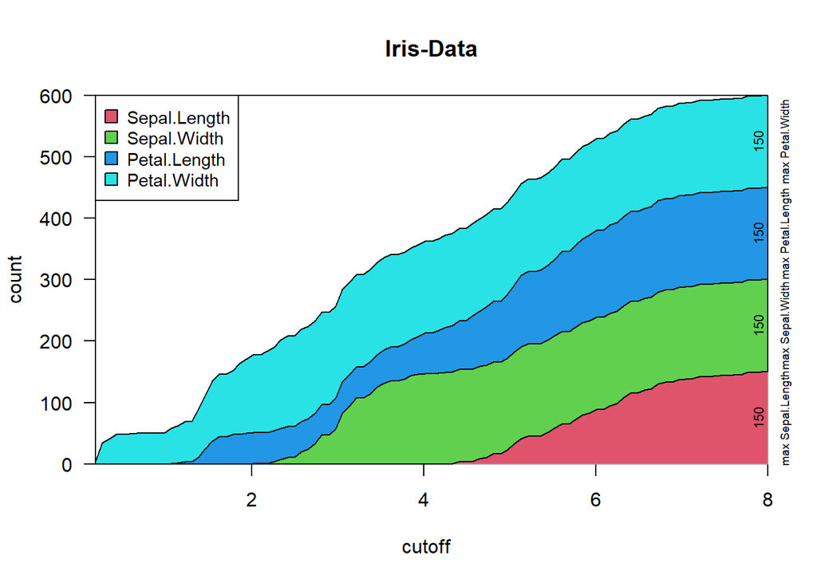

```r
staggerdCountsPlot(irisC[,], countsCol=colnames(iris)[1:4], tit="Iris-Data")
```

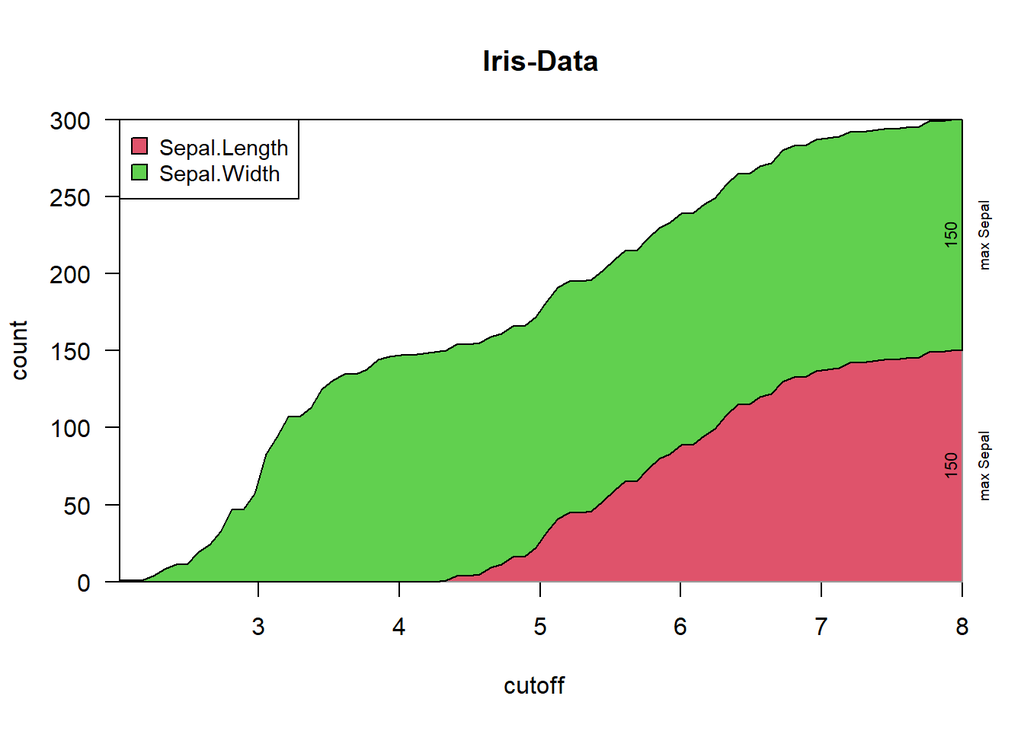

```r
staggerdCountsPlot(irisC[,], varCountNa="Sepal", tit="Iris-Data")
```

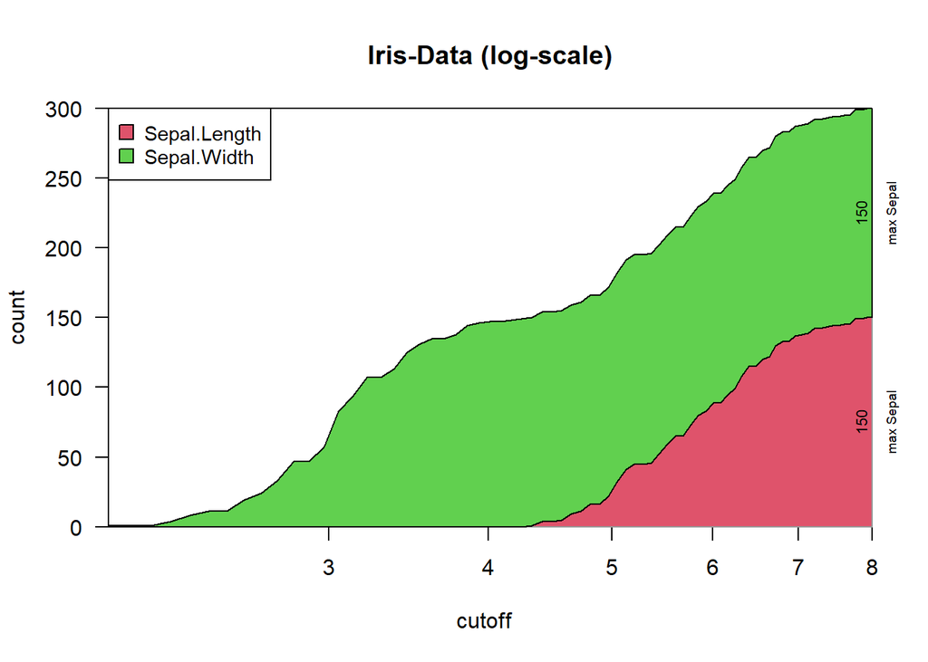

```r
staggerdCountsPlot(irisC[,], varCountNa="Sepal", tit="Iris-Data (log-scale)", logScale=TRUE)
```

## Compare Two Groups With Sub-Organisation Each

In real-world testing data have often some nested structure. For example repeated measures from a set of patients which can be organized as diseased and non-diseased. This plot allows to plot all values obtained from the each patient together, then organized by disease-groups.

For this example suppose the Iris-data were organized as 10 sets of 5 measures each (of course, in this case it is a pure hypothesis). Then, we can plot while highlighting the two factors (ie species and set of measurement). Basically we need to furnish with the main data two additional factors for the groupings. Note, that the 1st factor should contain the smaller sub-groups to visually inspect if there are any batch effects. This plot is not well adopted to big data (it will get too crowded).

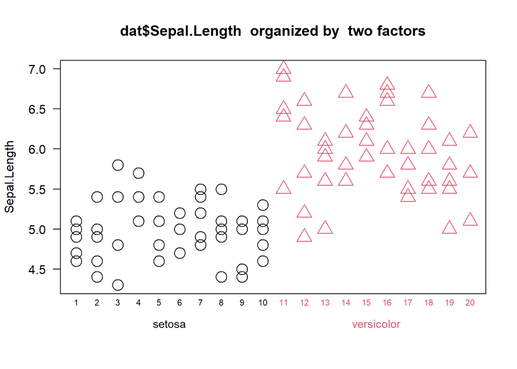

```r
dat <- iris[which(iris$Species %in% c("setosa","versicolor")),]
plotBy2Groups(dat$Sepal.Length, gl(2,50,labels=c("setosa","versicolor")),
  gl(20,5), yLab="Sepal.Length")
```

## Plotting Linear Regression And Confidence Intervals

The function *plotLinReg()* provides help to display a series of bivariate points given in ‘dat’ (multiple data formats possible), to model a [linear regression](https://en.wikipedia.org/wiki/Linear_regression) and plot the results.

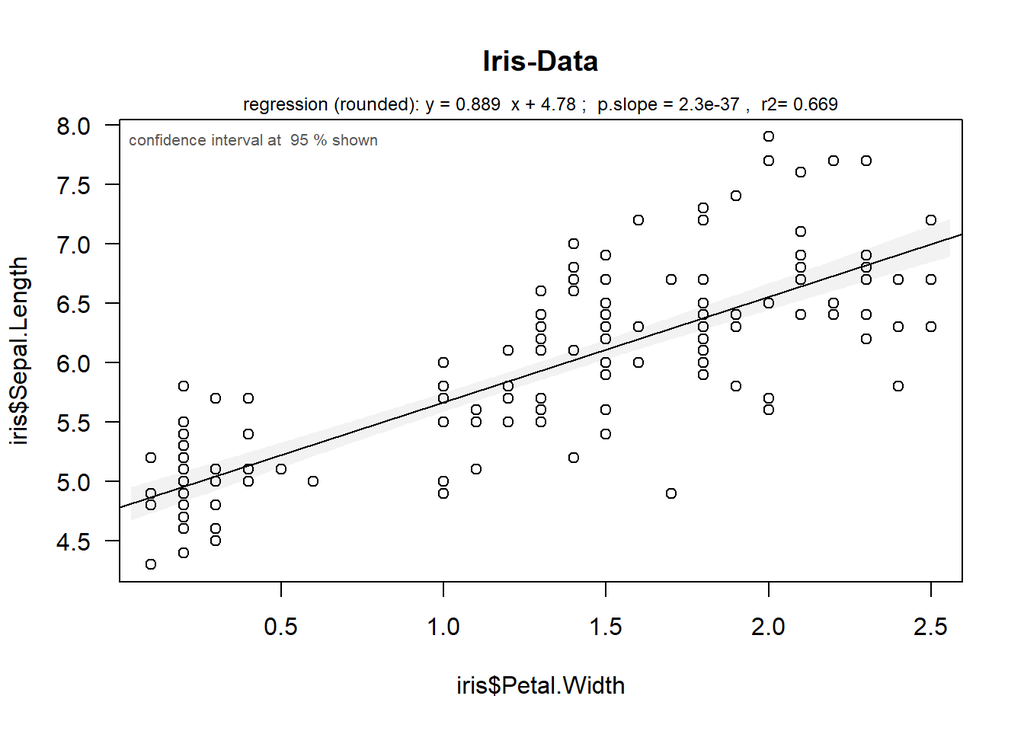

```r
plotLinReg(iris$Sepal.Length, iris$Petal.Width, tit="Iris-Data")
```

## Principal Components Analysis (PCA)

Principal components analysis, [PCA](https://en.wikipedia.org/wiki/Principal_component_analysis), is a very powerful method to investigate similarity and correlation in larger sets of data.  
Please note that several implementations exist in R (eg the function *prcomp()* in the base package stats or the package FactoMineR). We’ll start by looking at the plot produced with the basic function and FactoMineR, too.

Let’s look at the similarity of the 3 Iris-species from the Iris data-set.

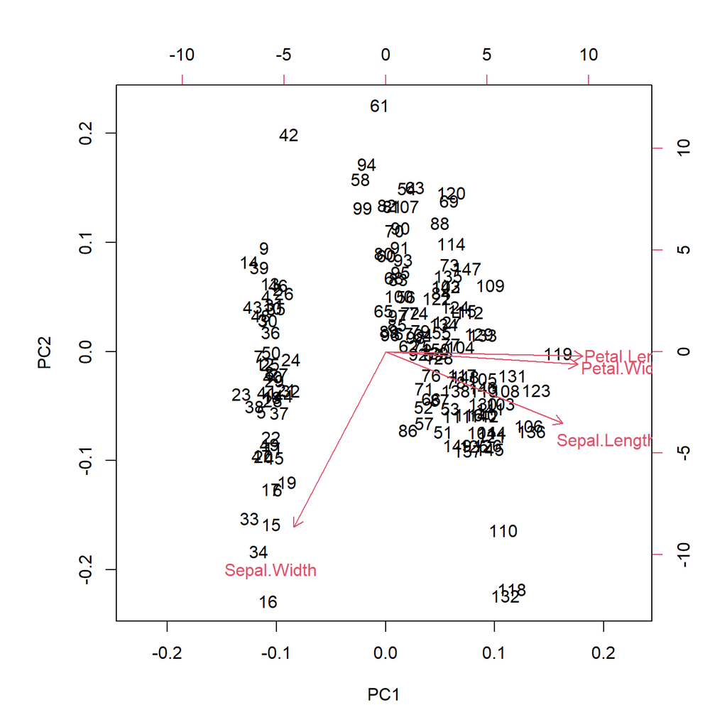

```r
## the basic way
iris.prc <- prcomp(iris[,1:4], scale.=TRUE)
biplot(iris.prc)              # traditional plot
```

Now we’ll try plotting the PCA using the package ‘FactoMineR’:

```r
## via FactoMineR
chPa <- c(requireNamespace("FactoMineR", quietly=TRUE), requireNamespace("dplyr", quietly=TRUE),
  requireNamespace("factoextra", quietly=TRUE), requireNamespace("ggpubr", quietly=TRUE) )
```

```
#>
#> Ignoring unknown labels:
#> • linetype : "Groups"
```

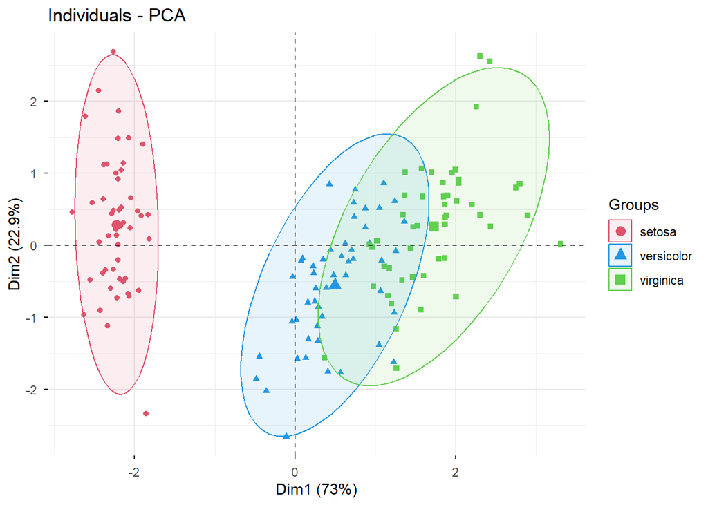

```r
if(all(chPa)) {
  library(FactoMineR); library(dplyr); library(factoextra)
  iris.Fac <- PCA(iris[,1:4],scale.unit=TRUE, graph=FALSE)
  iris.Fac2 <- try(fviz_pca_ind(iris.Fac, geom.ind="point", col.ind=iris$Species, palette=c(2,4,3),
    addEllipses=TRUE, legend.title="Groups"))
  if(inherits(iris.Fac2, "try-error")) message("Problem running factoextra ..") else {
    iris.Fac2 <- try(plot(iris.Fac2))
    if(inherits(iris.Fac2, "try-error")) message("A problem occured when trying to print from factoextra !!") }
} else message("You need to install packages 'dplyr', 'FactoMineR' and 'factoextra' for this figure ! ",
  "Check the messages of library() if there are other packages that may be missing (and need to get installed first)")
```

However, some sets of points do not always follow elliptic shapes. Note, that FactoMineR represented the 2nd principal component upside-down compared to the very first PCA figure. To facilitate comparisons, the function *plotPCAw* has an argument allowing to rotate/flip any principal component axis (see below).

### PCA out of wrGraph

Next we’ll explore how to plot PCA using the function `plotPCAw()` out of this package.

With more crowded data-sets it may be useful to rather highlight the more dense regions. For this reason this package proposes to use [bagplots](https://en.wikipedia.org/wiki/Bagplot) to highlight the region with 50% of data-points (in analogy to boxplots), a simple line draws the contour of the most distant points.

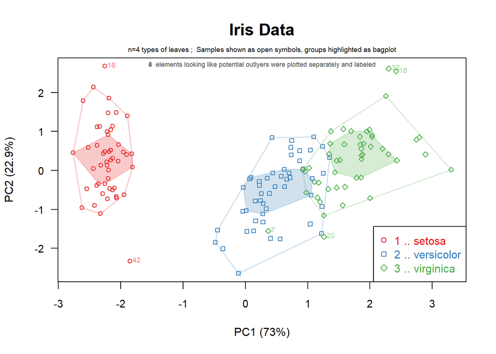

```r
## via wrGraph, similar to FactoMineR but with bagplots
plotPCAw(t(as.matrix(iris[,-5])), gl(3,50,labels=c("setosa","versicolor","virginica")),
  tit="Iris Data", rowTyName="types of leaves", suplFig=FALSE, cexTxt=1.3, rotatePC=2)
```

Thus, you can see in this case, there is some intersection between *versicolor* and *virginica* species, but the center regions stay apart. Of course, similar to boxplots, this representation is nor adopted/recommended for multi-modal distributions within one group of points. One might get some indications about this by starting the data-analysis by inspecting histograms or vioplots for each set/column of data.

You can also add the 3rd principal component and the Scree-plot :

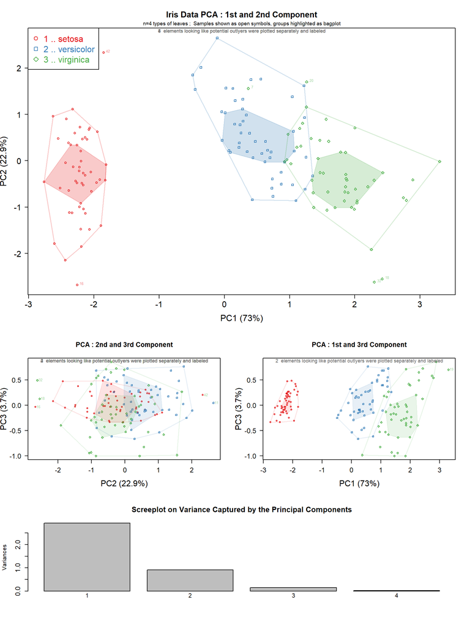

```r
## including 3rd component and Screeplot
plotPCAw(t(as.matrix(iris[,-5])), gl(3,50,labels=c("setosa","versicolor","virginica")),
  tit="Iris Data PCA", rowTyName="types of leaves", cexTxt=2)
```

### Label all points in PCA

In some cases it may be useful to identify all individual points on a plot using the argument *pointLabelPar*.

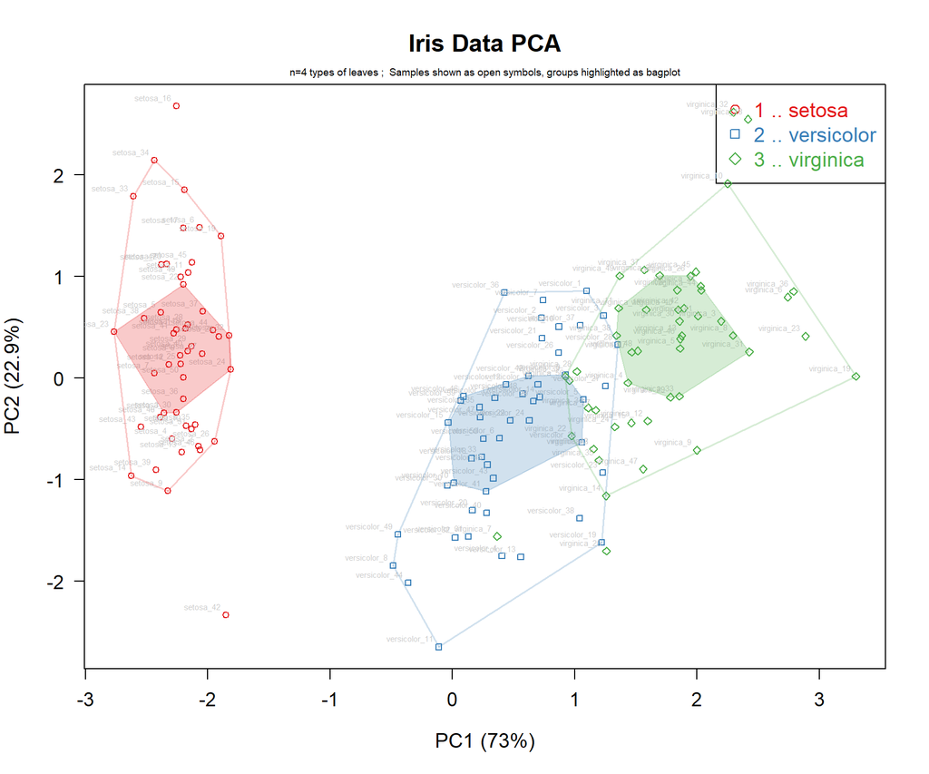

```r
## creat copy of data and add rownames
irisD <- as.matrix(iris[,-5])
rownames(irisD) <- paste(iris$Species, rep(1:50,3), sep="_")
## plot
plotPCAw(t(irisD), gl(3,50,labels=c("setosa","versicolor","virginica")), tit="Iris Data PCA",
  rowTyName="types of leaves", suplFig=FALSE, cexTxt=1.6, rotatePC=2, pointLabelPar=list(textCex=0.48))
```

## MA-Plot

The aim of [MA-plots](https://en.wikipedia.org/wiki/MA_plot) consists in displaying a relative change on one axis (ordinate) while showing the absolute (mean) value on the x-axis (abscissa). This plot is very useful when inspecting larger data-sets for random or systematic effects, numerous implementations for specific applications exist (eg *plotMA* in [DEseq2](https://bioconductor.org/packages/release/bioc/html/DESeq2.html)). The version presented here is rather generic and uses transparent points to avoid getting plots too crowded.

First, let’s generate some toy data:

```r
## toy data
set.seed(2005); mat <- matrix(round(runif(2400),3), ncol=6)
mat[11:90,4:6] <- mat[11:90,4:6] +round(abs(rnorm(80)),3)
mat[11:90,] <- mat[11:90,] +0.3
dimnames(mat) <- list(paste("li",1:nrow(mat),sep="_"),paste(rep(letters[1:2],each=3),1:6,sep=""))
## assume 2 groups with 3 samples each
matMeans <- round(cbind(A=rowMeans(mat[,1:3]), B=rowMeans(mat[,4:6])),4)
```

One way of using the function *MAplotW()* is by providing (explicitely) the M- and A-values. By default a threshold-line is drawn for a fold-change of 1.5x (which on log2 scale apprears at +/- 0.58).

```r
## now we are ready to plot, M-values can be obtained by subtracting thr group-means
MAplotW(M=matMeans[,1] -matMeans[,2], A=rowMeans(mat))
```

[output not shown]

The function *MAplotW* may also be used to conveniently inspect results from t-tests performed with the package wrMisc or from the very popular package [limma](https://www.bioconductor.org/packages/release/bioc/html/limma.html).

```r
## assume 2 groups with 3 samples each and run moderated t-test (from package 'limma')
tRes <- wrMisc::moderTest2grp(mat,  gl(2, 3, labels=LETTERS[1:2]), addResults=c("FDR","Mval","means"))
```

This object contains data for different types of plots (MA-plot, Volcano-Plot, etc ..), let’s also mark the names of those passing the fold-change threshold.

```r
## basic default MA-plot of object from testing :
try(MAplotW(tRes))
```

```
#> Please install latest version of wrMisc (> 2.0.1) from CRAN
```

```r
## convenient way, change fold-change threshold to 2x and mark who is beyond :
try(MAplotW(tRes, FCth=2, namesNBest="passFC"))
```

```
#> Please install latest version of wrMisc (> 2.0.1) from CRAN
```

## Volcano-Plot

This plot is very useful when inspecting larger data-sets for random or systematic effects.  
Points with high log-ratios (ie high fold-change) may not always have enthusiastic p-values, too. Many times such divergences may point to high intra-group variability. Numerous implementations for specific applications exist (eg the package [EnhancedVolcano](https://bioconductor.org/packages/release/bioc/html/EnhancedVolcano.html)). The version presented here is rather generic and uses transparent points to avoid getting plots too crowded. Furthermore, this version has the advantage to take all information needed directly in MArrayLM-objects, like the output of moderTest2grp() or moderTestXgrp().

Please note that the examples use faily small toy-data where the estimation of local fdr-values (lfdr) may not be optimal. For this reason the functions for estimating the lfdr give warning messages which are suppressed in the exmaples below. In real world testing the user may either switch to the frequenly used Bejamini-Hochberg (global) FDR or should interprete results on lfdr-level with caution.

```r
## let's generate some toy data
set.seed(2005); mat <- matrix(round(runif(900),2), ncol=9)
rownames(mat) <- paste0(rep(letters[1:25],each=4), rep(letters[2:26],4))
mat[1:50,4:6] <- mat[1:50,4:6] + rep(c(-1,1)*0.1,25)
mat[3:7,4:9] <- mat[3:7,4:9] + 0.7
mat[11:15,1:6] <- mat[11:15,1:6] - 0.7

## assume 2 groups with 3 samples each
gr3 <- gl(3,3,labels=c("C","A","B"))
tRes2 <- suppressWarnings(moderTest2grp(mat[,1:6], gl(2,3)))
```

```
#> moderTest2grp : Please NOTE that fdrtool() (from package fdrtool) considers that there are TOO FEW input test statistics for reliable FDR calculations !   (..originally giving a warning)
```

```r
try(VolcanoPlotW(tRes2))
```

```
#> Please install latest version of wrMisc (> 2.0.1) from CRAN
```

```r
# now with thresholds, labels and arrow for expected ratio
try(VolcanoPlotW(tRes2, FCth=1.3, FdrThrs=0.2, namesNBest="pass", expFCarrow=c(0.75,2)))
```

```
#> Please install latest version of wrMisc (> 2.0.1) from CRAN
```

Note, that this exampe is very small and for this reason the function *fdrtool()* used internally issues some warnings since the estimation of lfdr is not optimal.

```r
## assume 3 groups with 3 samples each
tRes <- suppressWarnings(moderTestXgrp(mat, gr3))

layout(matrix(1:2, nrow=1))
try(VolcanoPlotW(tRes, FCth=1.3, FdrThrs=0.2, useComp=2))
```

```
#> Please install latest version of wrMisc (> 2.0.1) from CRAN
```

```r
try(VolcanoPlotW(tRes, FCth=1.3, FdrThrs=0.2, useComp=3))
```

```
#> Please install latest version of wrMisc (> 2.0.1) from CRAN
```

## Standalone html Page With Plot And Mouse-Over Interactive Features

The idea of this function dates before somehow similar applications were made possible using [Shiny](https://shiny.posit.co/). In this case the original idea was simply to provide help to identify points in a plot and display via mouse-over labels to display and by providing clickable links. To do so, very simple html documents are created which display a separately saved image and have a section indicating at which location of the figure which information should be displayed as mouse-over and providing the clickable links. In high-throughput biology many times researchers want quickly know which protein or gene a given point in a graphic corresponds and being able to get further information on this protein or gene via links to [UniProt](https://www.uniprot.org) or [GenBank](https://www.ncbi.nlm.nih.gov/genbank).

As this functionality was made for separate html documents it’s output cannot be easily integrated into a vignette like this one. To generate such a simple mouse-over interactive html document, the user is invited to run the code of this vignette. At the last step you could ask R to open the interactive html page in the default browser.

Concerning the path provided in the argument *pngFileNa* of the function *mouseOverHtmlFile*: In a real world case, you might want to choose other locations to save files rather than R-temp which will be deleted when closing your instance of R. It is also possible to work with relative paths (eg by giving the png-filename without path). Then the resultant html will simply require the png-file to be in the same directory as the html itself, and similarly for the clickable links. This results in files that are very easy to distribute to other people, in particular if the clickable links are pointing to the internet, however, the png-file always needs to be in the same directory as the html … If you have the possibility to make the png-file accessible through a url, you could also provide this url.

The example below shows usage when specifying absolute paths. Please note that the resulting html will not display the image if your browser cannot access the image any more.

Unfortunately the resulting html couldn’t get integrated in this package vignette. You need to open in (separetely) using a browser or launch a browser out of R (see commented last line of code).

```r
## Let's make some toy data
df1 <- data.frame(id=letters[1:10], x=1:10, y=rep(5,10) ,mou=paste("point",letters[1:10]),
  link=file.path(tempdir(),paste(LETTERS[1:10],".html",sep="")),stringsAsFactors=FALSE)
## here we'll use R's tempdir, later you may want to choose other locations
pngFile <- file.path(tempdir(),"test01.png")
png(pngFile, width=800, height=600, res=72)
## here we'll just plot a set of horiontal points ...
plot(df1[,2:3], las=1, main="test01")
dev.off()
```

```r
## Note : Special characters should be converted for proper display in html during mouse-over
df1$mou <- htmlSpecCharConv(df1$mou)
## Let's add the x- and y-coordiates of the points in pixels to the data.frame
df1 <- cbind(df1, convertPlotCoordPix(x=df1[,2], y=df1[,3], plotD=c(800,600), plotRes=72))
```

```
#> convertPlotCoordPix : Supl params : mar=6.2,4,4,2  dim=800x600   res=72
```

```r
head(df1)
```

```
#>   id x y     mou                                                      link xPix
#> 1  a 1 5 point a C:\\Users\\wraff\\AppData\\Local\\Temp\\RtmpwTED2l/A.html   81
#> 2  b 2 5 point b C:\\Users\\wraff\\AppData\\Local\\Temp\\RtmpwTED2l/B.html  155
#> 3  c 3 5 point c C:\\Users\\wraff\\AppData\\Local\\Temp\\RtmpwTED2l/C.html  229
#> 4  d 4 5 point d C:\\Users\\wraff\\AppData\\Local\\Temp\\RtmpwTED2l/D.html  303
#> 5  e 5 5 point e C:\\Users\\wraff\\AppData\\Local\\Temp\\RtmpwTED2l/E.html  377
#> 6  f 6 5 point f C:\\Users\\wraff\\AppData\\Local\\Temp\\RtmpwTED2l/F.html  451
#>   yPix
#> 1  284
#> 2  284
#> 3  284
#> 4  284
#> 5  284
#> 6  284
```

```r
## Now make the html-page allowing to display mouse-over to the png made before
htmFile <- file.path(tempdir(),"test01.html")
mouseOverHtmlFile(df1, pngFile, HtmFileNa=htmFile, pxDiam=15,
  textAtStart="Points in the figure are interactive to mouse-over ...",
  textAtEnd="and/or may contain links")
## We still need to make some toy links
for(i in 1:nrow(df1)) cat(paste("point no ",i," : ",df1[i,1]," x=",df1[i,2]," y=",
  df1[i,3],sep=""), file=df1$link[i])
## Now we are ready to open the html file using any browser ..
#from within R# browseURL(htmFile)
```

## Acknowledgements

The author would like to acknowledge the support by the [IGBMC](https://www.igbmc.fr) (CNRS UMR 7104, Inserm U 1258, UdS), [CNRS](http://www.cnrs.fr/en), [Université de Strasbourg (UdS)](https://www.unistra.fr/fr) and [Inserm](https://www.inserm.fr). and of course all collegues from the [IGBMC proteomics platform](https://www.igbmc.fr/en/plateformes-technologiques/translate-to-english-proteomique). The author wishes to thank the [CRAN-staff](https://CRAN.R-project.org) for all their help and their efforts in maintaining this repository of R-packages.

Thank you for you interest in this package. This package is constantly evolving, new functions may get added to the next version.

## Appendix: Session-Info

For completeness, here detailed documentation of versions used to produce this document, produced by the function sessionInfo().

[session information not shown]